# 1. Exploratory Data Analysis

Understanding the data before statistical analysis

Author

Gustavo Roa

# Exploratory Data Analysis

Before conducting a statistical analysis, we first need to understand the data.

**Exploratory Data Analysis (EDA)** uses numerical summaries and graphs to examine the main features of a dataset before fitting a statistical model.

In this section, we will explore grain yield using:

- Numerical summaries
- Histograms
- Box plots

The same workflow can be applied to many agricultural and biological datasets.

## Learning objectives

By the end of this section, you should be able to:

- Inspect the structure of a dataset.
- Summarize a continuous variable.
- Describe the center and spread of a distribution.
- Use histograms and box plots to explore data.
- Compare distributions among groups.
- Identify potentially unusual observations.
- Explain why EDA should come before statistical modeling.

# Why explore the data?

Statistical analysis should begin with a **research question**, not with a statistical test.

Before fitting a model, ask:

> **What does the data look like?**

For a continuous variable such as grain yield, we may want to know:

- Where are most observations located?
- How much variation is present?
- Is the distribution symmetric or skewed?
- Are there multiple peaks?
- Are there unusually high or low observations?
- Do groups appear to have similar variability?

EDA helps us answer these questions and identify potential problems before formal analysis.

# Load the required packages

We will use `ggplot2` for visualization and `readxl` to import the Excel dataset.

```r
# Load packages for visualization and Excel files
library(ggplot2)
library(readxl)
```

# Load the data

The example dataset is provided as an Excel file. We will import the worksheet named `data`.

```r
# Import the data from the Excel worksheet
AllData <- read_excel(
  "Data_example.xlsx",
  sheet = "data"
)

# Check the structure and variable types
str(AllData)
```

```
tibble [20 × 11] (S3: tbl_df/tbl/data.frame)
 $ year             : num [1:20] 2022 2022 2022 2022 2022 ...
 $ location         : chr [1:20] "Ashland" "Ashland" "Ashland" "Ashland" ...
 $ block            : num [1:20] 1 1 1 1 1 2 2 2 2 2 ...
 $ S_rate_kg_ha     : num [1:20] 34 11 45 22 0 0 34 22 11 45 ...
 $ grain_yield_Mg_ha: num [1:20] 9.04 10.66 11.25 10.06 7.75 ...
 $ biomass_V6_Mg_ha : num [1:20] 0.39 0.46 0.48 0.38 0.69 0.35 0.49 0.75 0.68 0.59 ...
 $ biomass_R1_Mg_ha : num [1:20] 7.82 8.52 7.6 7.47 10.3 ...
 $ S_conc_V6_pct    : num [1:20] 0.28 0.24 0.29 0.25 0.23 0.25 0.25 0.24 0.24 0.25 ...
 $ N_conc_V6_pct    : num [1:20] 3.86 3.65 3.78 3.67 3.74 3.93 3.8 3.68 3.87 3.66 ...
 $ S_conc_R1_pct    : num [1:20] 0.15 0.13 0.14 0.12 0.13 0.16 0.13 0.13 0.11 0.14 ...
 $ N_conc_R1_pct    : num [1:20] 1.7 1.57 1.7 1.38 1.59 1.81 1.62 1.6 1.41 1.63 ...
```

## Take a first look

Before analyzing the data, inspect the first observations.

```r
# Display the first six rows
head(AllData)
```

```
# A tibble: 6 × 11
   year location block S_rate_kg_ha grain_yield_Mg_ha biomass_V6_Mg_ha
  <dbl> <chr>    <dbl>        <dbl>             <dbl>            <dbl>
1  2022 Ashland      1           34              9.04             0.39
2  2022 Ashland      1           11             10.7              0.46
3  2022 Ashland      1           45             11.3              0.48
4  2022 Ashland      1           22             10.1              0.38
5  2022 Ashland      1            0              7.75             0.69
6  2022 Ashland      2            0              8.86             0.35
# ℹ 5 more variables: biomass_R1_Mg_ha <dbl>, S_conc_V6_pct <dbl>,
#   N_conc_V6_pct <dbl>, S_conc_R1_pct <dbl>, N_conc_R1_pct <dbl>
```

# Numerical summary

A numerical summary provides a quick description of a variable.

For grain yield, `summary()` provides:

- Minimum
- First quartile (Q1)
- Median
- Mean
- Third quartile (Q3)
- Maximum

```
   Min. 1st Qu.  Median    Mean 3rd Qu.    Max.
  5.367   9.900  10.731  10.526  11.545  13.008
```

### Center

The **mean** and **median** describe the center of the distribution.

- **Mean:** arithmetic average of the observations.
- **Median:** middle observation when the data are ordered.

### Spread

The minimum and maximum describe the observed range.

The **interquartile range (IQR)** describes the middle 50% of the observations:

$$IQR = Q3 - Q1$$

Numerical summaries are useful, but they do not show the shape of the distribution. Graphs help us see these patterns.

# Histogram

## What is a histogram?

A histogram shows how observations are distributed across a continuous variable.

The range of the variable is divided into **bins**, and the height of each bar represents the number of observations within each bin.

A histogram can help us examine:

- Center
- Spread
- Shape
- Skewness
- Multiple peaks
- Potentially unusual observations

## Create a histogram

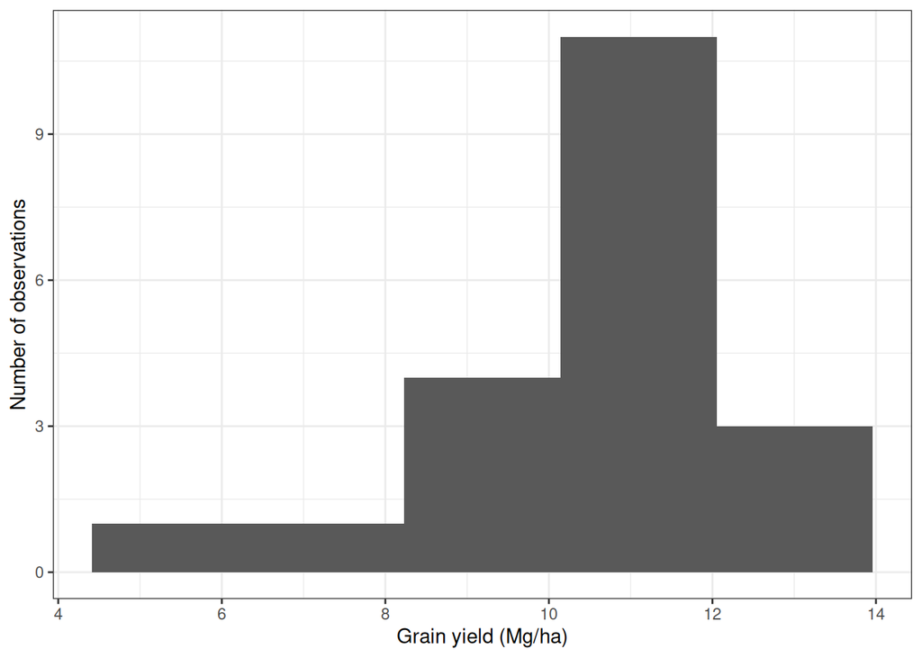

## How do we read the histogram?

When looking at a histogram, ask:

1. Where are most observations concentrated?
2. How spread out are the observations?
3. Is the distribution approximately symmetric?
4. Is there evidence of skewness?
5. Are there multiple peaks?
6. Are there potentially unusual observations?

Do not focus only on whether the data are “normal” or “not normal.” First, describe the features you see in the distribution.

# Box plot

## What is a box plot?

A box plot provides a compact summary of a continuous variable.

| Component | Meaning |
| --- | --- |
| Median | Line inside the box |
| Q1 | Lower edge of the box |
| Q3 | Upper edge of the box |
| IQR | Q3 − Q1 |
| Whiskers | Extend toward observations within the usual limits |
| Points beyond whiskers | Potentially unusual observations |

The box contains the **middle 50% of the observations**.

## Create a box plot

A box plot is particularly useful for comparing grain yield among sulfur rates.

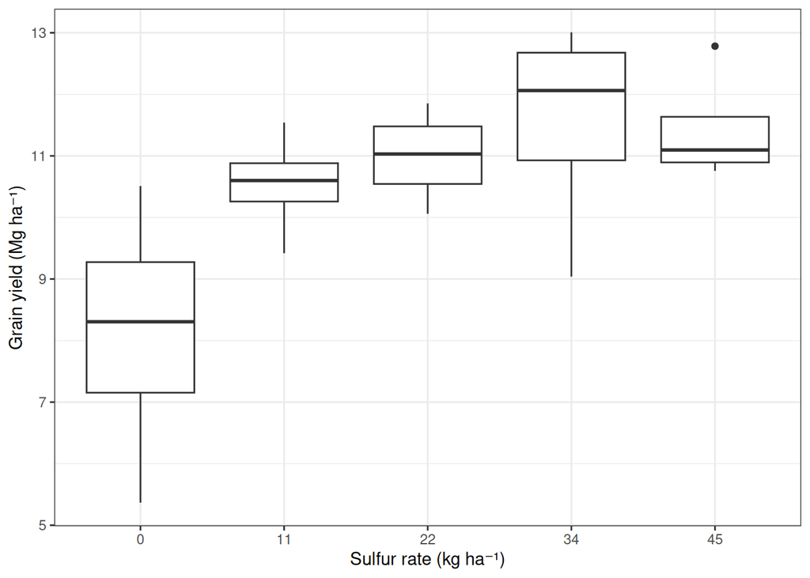

## How do we read the box plot?

Use the box plot to compare:

- Median grain yield among treatments
- Spread within each treatment
- Differences in variability
- Potentially unusual observations

# Why EDA comes before modeling

EDA helps us understand the data before fitting a statistical model.

It can reveal:

- Missing or incorrect values
- Unexpected treatment levels
- Unusual observations
- Skewed distributions
- Differences in variability
- Patterns that may affect model choice

EDA does not replace statistical modeling. It helps us make better decisions about the analysis that follows.

# Exercise

Now apply what you have learned to the dataset.

## Exercise 1.1: Numerical summary

Use `summary()` to describe `grain_yield_Mg_ha`.

Identify:

- Mean
- Median
- Minimum
- Maximum
- First quartile (Q1)
- Third quartile (Q3)

Try it yourself:

```r
# Summarize grain yield
summary(AllData$______________)
```

**TipShow solution**

```r
# Summarize grain yield
summary(AllData$grain_yield_Mg_ha)
```

```
   Min. 1st Qu.  Median    Mean 3rd Qu.    Max.
  5.367   9.900  10.731  10.526  11.545  13.008
```

## Exercise 1.2: Histogram

Create a histogram of grain yield.

Your figure should include:

- An appropriate number of bins
- A descriptive x-axis
- A y-axis showing the number of observations
- `theme_bw()`

Try it yourself:

```r
# Create a histogram of grain yield
ggplot(
  AllData,
  aes(x = ____________)
) +
  geom_histogram(bins = ___) +
  labs(
    x = "____________",
    y = "____________"
  ) +
  theme_bw()
```

**TipShow solution**

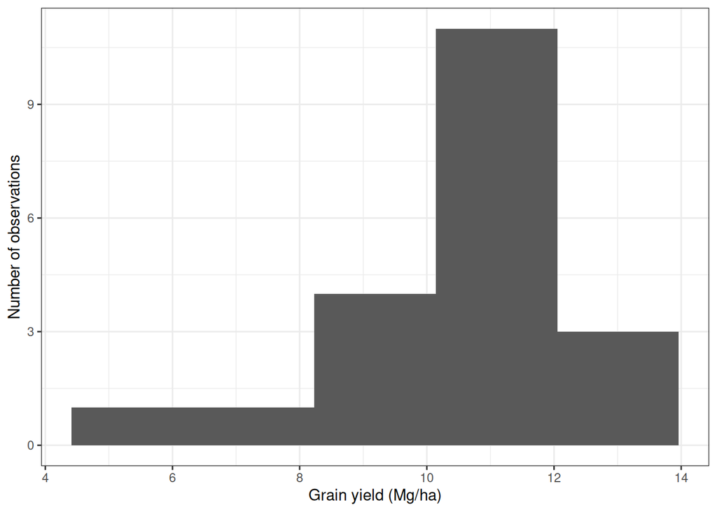

```r
# Create a histogram of grain yield
ggplot(
  AllData,
  aes(x = grain_yield_Mg_ha)
) +
  geom_histogram(bins = 5) +
  labs(
    x = "Grain yield (Mg/ha)",
    y = "Number of observations"
  ) +
  theme_bw()
```

## Exercise 1.3: Box plot

Create a box plot comparing grain yield among sulfur rates.

Try it yourself:

```r
# Create a box plot by sulfur rate
ggplot(
  AllData,
  aes(
    x = ____________,
    y = ____________
  )
) +
  geom_boxplot() +
  labs(
    x = "____________",
    y = "____________"
  ) +
  theme_bw()
```

**TipShow solution**

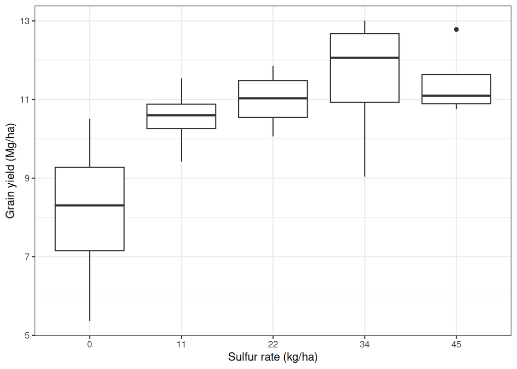

```r
# Create a box plot by sulfur rate
ggplot(
  AllData,
  aes(
    x = factor(S_rate_kg_ha),
    y = grain_yield_Mg_ha
  )
) +
  geom_boxplot() +
  labs(
    x = "Sulfur rate (kg/ha)",
    y = "Grain yield (Mg/ha)"
  ) +
  theme_bw()
```

## Exercise 1.4: Interpret the results

Use your numerical summary and graphs to answer:

1. What is the typical grain yield?
2. How much variation is present?
3. Which sulfur rate has the highest median yield?
4. Are there any potentially unusual observations?

> **Important:** At this stage, we are describing the data. We are not conducting a statistical test or making conclusions about treatment effects.

# Key takeaways

- Numerical summaries describe the center and spread of the data.
- Histograms help us examine the shape of a distribution.
- Box plots help us summarize and compare groups.
- Unusual observations should be investigated, not automatically removed.
- EDA should come before formal statistical modeling.

> **Understand your data before asking a statistical model to explain it.**

# Next section

In the next section, we will move from exploring a single variable to examining the relationship between **different continuous variables**.

We will use **correlation analysis** to quantify the strength and direction of relationships between agronomic variables.